# Torrance, CA

Allison Joseph

9/18/2017

Torrance is a coastal community in southwestern Los Angeles County sharing the climate and geographical features common to the Greater Los Angeles area. Torrance has about 1.5 miles of beaches on the Pacific Ocean and a heavily industrialized inland area (California Climate Change Center, 2010). Thus, cooling can result from ocean breezes, while heating can result from industrialization. Torrance serves as a model for California coastal cities, demonstrating an overall increase in temperature because of climate change. Coastal cities are particularly vulnerable to natural hazards, including storms, extreme high tides, and rising sea levels resulting from global climate change (IPCC, 2014).

## Models

Using data from the National Oceanic and Atmospheric Association (NOAA) free online archive of historical weather and climate data from stations around the globe, climate data from January 1, 1932 to September 6, 2017 for station USW00003122 in Torrance, California was examined.

RStudio software was used to summarize, evaluate, and graphically present the data, creating a linear model and a trendline. Analysis of maximum and minimum temperatures (Fahrenheit) by month from 1932 to 2017 were used to account for daily and seasonal fluctuations in temperature.

Using the null hypothesis method, a standard scientific convention, the data was used to determine if there is a trend between time and temperature. The null hypothesis states that there is no relationship between temperature and time. The alternative hypothesis states that there is a relationship between temperature and time. Therefore, if the probability value (p-value) calculated is less than 0.05, the null hypothesis is considered violated and a relationship can be assumed.

## Daily Data

The data shows a daily increase of .00005 degrees Farenheit, with a p-value of less than 0.0001. Although such an increase does not seem to be that high, when multiplied by 365 (days) for 1 year, the average yearly increase was 0.02 degrees Farenheit. Over 100 years, the temperature increase for Torrance would be about 2 degrees Farenheit.

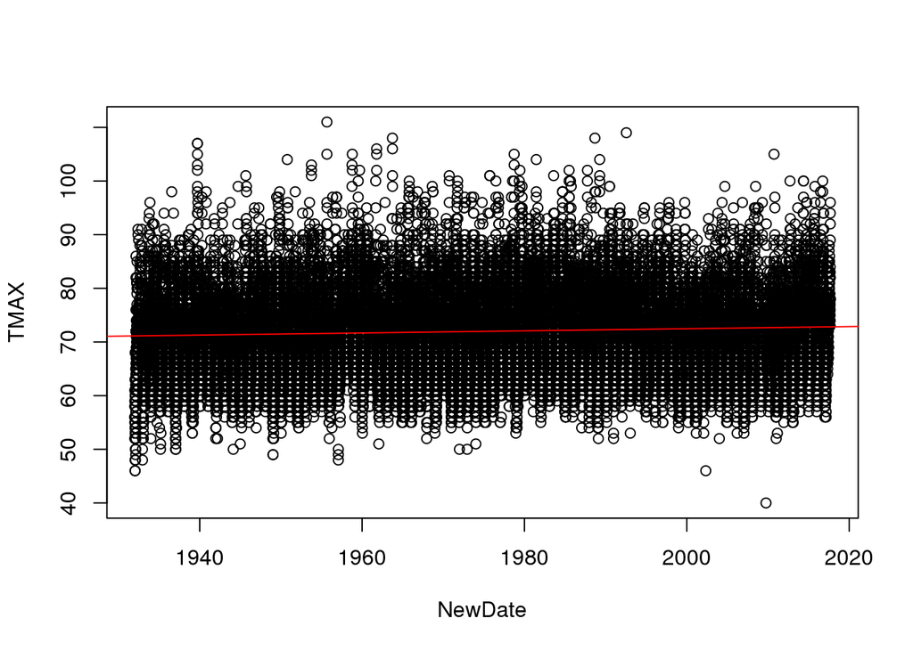

## Monthly Max Temperature Averages

Janruary was chosen as an example month, because there is a trend for both maximum and minimum values (null hypothesis is violated). January shows a .04 monthly increase, with a p value of less than 0.05. Thus, January rejects the null hypothesis, showing a trend between time and temperature.

```
## 'data.frame':    1011 obs. of  5 variables:
##  $ Month: chr  "01" "02" "03" "04" ...
##  $ Year : chr  "1932" "1932" "1932" "1932" ...
##  $ TMAX : num  54.9 60.7 68.7 70.1 71.2 ...
##  $ YEAR : num  1932 1932 1932 1932 1932 ...
##  $ MONTH: num  1 2 3 4 5 6 7 8 10 11 ...
```

```
##   Month Year     TMAX YEAR MONTH  NewDate
## 1    01 1932 4.711231 1932     1 1932.000
## 2    02 1932 9.659473 1932     2 1932.083
## 3    03 1932 5.292722 1932     3 1932.167
## 4    04 1932 6.791137 1932     4 1932.250
## 5    05 1932 5.931118 1932     5 1932.333
## 6    06 1932 4.269782 1932     6 1932.417
```

```
##
## Call:
## lm(formula = TMAX ~ YEAR, data = MonthlyTMAXMean[MonthlyTMAXMean$Month ==
##     "01", ])
##
## Residuals:
##     Min      1Q  Median      3Q     Max
## -9.3466 -1.9368 -0.2218  1.9847  6.9893
##
## Coefficients:
##              Estimate Std. Error t value Pr(>|t|)
## (Intercept) -16.49211   27.69132  -0.596  0.55308
## YEAR          0.04181    0.01403   2.981  0.00377 **
## ---
## Signif. codes:  0 '***' 0.001 '**' 0.01 '*' 0.05 '.' 0.1 ' ' 1
##
## Residual standard error: 3.192 on 83 degrees of freedom
## Multiple R-squared:  0.09669,    Adjusted R-squared:  0.08581
## F-statistic: 8.885 on 1 and 83 DF,  p-value: 0.003772
```

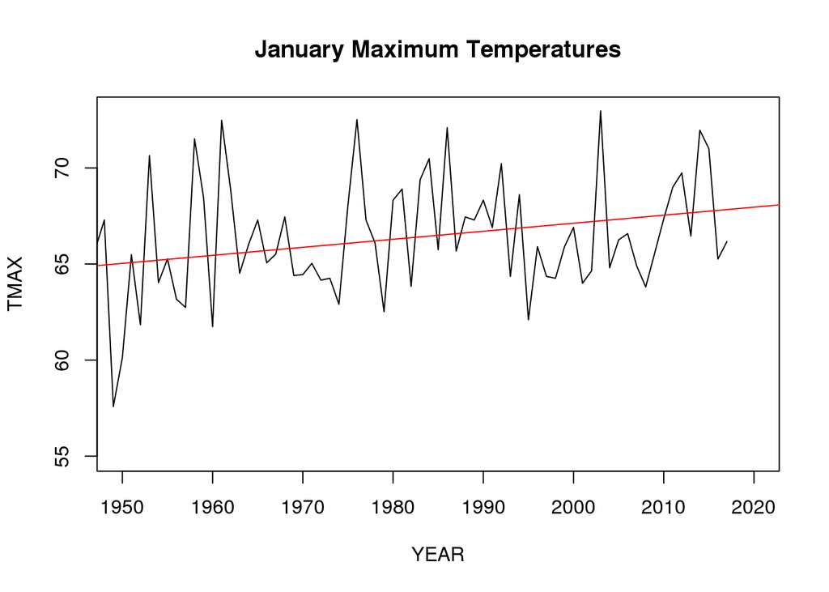

## Analyis of Maximum Temperature Data

January, March, April, June, and December (5/12 months) violate the null hypothesis.

The data shows that Torrance is generally warming, an increase in temperature exists for January, March, April, and June, supporting the idea that global warming is occurring.

In contrast, December shows a decrease in temperature. December’s cooling can be understood due to seasonal variation, as temperatures tend to decrease during the winter.

## Minimum Monthly Temperatures

Janruary shows a .08 monthly increase with a p value of less than 0.0001. The null hypothesis can be rejected, showing there is a trend between time and temperature.

```
##   Month Year     TMIN YEAR MONTH
## 1    01 1932 35.41935 1932     1
## 2    02 1932 41.06897 1932     2
## 3    03 1932 44.12903 1932     3
## 4    04 1932 43.56667 1932     4
## 5    05 1932 51.10000 1932     5
## 6    06 1932 52.46667 1932     6
```

```
##
## Call:
## lm(formula = TMIN ~ YEAR, data = MonthlyTMINMean[MonthlyTMINMean$Month ==
##     "01", ])
##
## Residuals:
##     Min      1Q  Median      3Q     Max
## -7.5082 -1.2429  0.0172  1.5311  5.7544
##
## Coefficients:
##               Estimate Std. Error t value Pr(>|t|)
## (Intercept) -126.41912   22.57888  -5.599 2.72e-07 ***
## YEAR           0.08652    0.01144   7.566 4.74e-11 ***
## ---
## Signif. codes:  0 '***' 0.001 '**' 0.01 '*' 0.05 '.' 0.1 ' ' 1
##
## Residual standard error: 2.603 on 83 degrees of freedom
## Multiple R-squared:  0.4081, Adjusted R-squared:  0.401
## F-statistic: 57.24 on 1 and 83 DF,  p-value: 4.736e-11
```

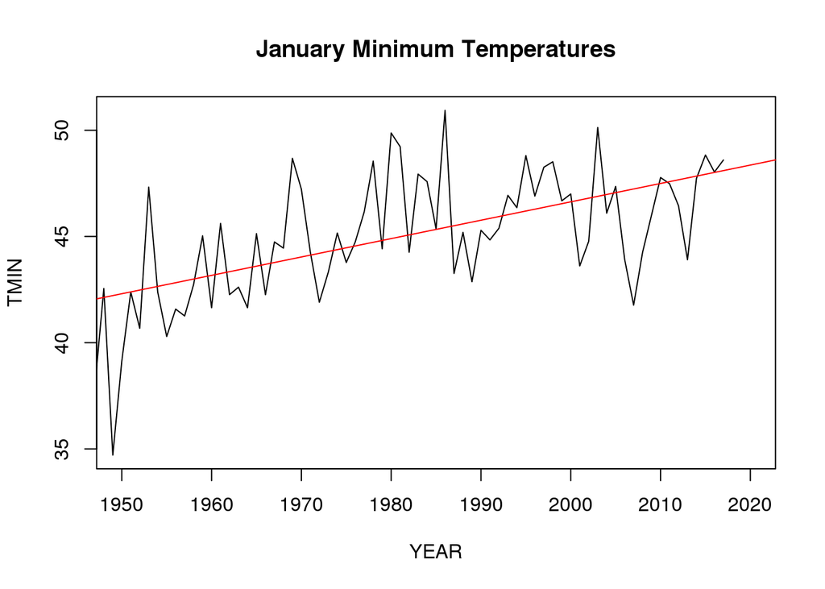

## Minimum Monthly Temperatures Data Analysis

For Torrance, all of the minimum temperatures are increasing, with a p value of less than .05. Thus, the null hypothesis is rejected, therefore, temperature is increasing with date.

When comparing January’s temperature increase, the slope for Janruary’s maximum temperature was .04, while January’s minimum temperature had a greater slope of .08. The rate of temperature increase for all monthly minimum temperatures was greater than their maximum temperature counterpart.

Thus, nights are warming at a faster rate than the daytime temperatures. Torrance reflects a pattern known as asymmetric warming, as minimum temperatures are increasing at a faster rate than maximum temperatures.

This lack of nighttime cooling has characterized recent heat waves in California, increasing the duratuin of such extremem events to 5 days or longer. This places huge strains on California health and infrastructure.

## What does this mean for Torrance?

It was difficult to find literature on the issues plaguing Torrance in particular. Yet, as a part of the greater Los Angeles county, Torrance can serve as a model for other Los Angeles coastal cities facing climate change.

One important impact linked to increased temperatures is sea level rise. For the Los Angeles (L.A.) region, sea leve rise matches global projections with an increase of 0.1 - 0.6 m (5 - 24 inches) from 2000 to 2050 and 0.4 - 1.7 m (17 - 66 inches) from 2000 to 2100.

In brief, sea level rise poses a threat to Torrance’s economic, social and environmental wellbeing.

## Economic Impcats

The economic cost of increased sea level rise is of concern for not only the city of Torrance, but for the larger Los Angeles area. California also has the nation’s largest ocean economy, valued at over $44 billion per year, providing numerous ports and shipping areas that serve the nation and the world. Sea level rise could cause a variety of impacts to ports, including flooding of port infrastructure and damage to piers and marina facilities from wave action and higher water levels.

Sea level rise could also lead to a loss of public access and recreational opportunities due to permanent inundation, periodic flooding, or erosion of beaches, recreational areas, or trails. In areas where beaches cannot migrate inland due to development or more resistant landforms, beaches will become narrower or will disappear completely (California Coastal Commission, 2017).

An analysis of 51 public beaches in Los Angeles County and Orange County evaluated the economic impacts of permanent beach loss caused by sea level rise and temporary beach inundation by extreme coastal storms. The study integrated a beach attendance model and a beach sediment model to predict that a 1 meter sea level rise by 2100 can reduce more than 500 thousand beach visits by Southern California residents each year, resulting in an economic loss of $40 million to $63 million annually. In addition, severe wind storms can also reduce beach attendance by more than 300 thousand, resulting in a $37 million economic loss (Finkl, 2016).

In addition, sea level rise will also result in property and infrastructure damage. Rising sea levels and the corresponding increased erosion of bluffs and shorelines will result in a greater instability of coastal structures. Such infrastructure as roads, hospitals, schools, emergency facilities, wastewater treatment plants, and power plants are at increased risk. The replacement value of property at risk from sea level rise for the California coast is approximately $100 billion. Future development for industry and commerce will be also be limited as a result of flooding and erosion (Parker, 2017).

## Social Impacts

In addition, continued access to the coast is important to the health and well-being of the public, as people’s safety, lives, daily movement patterns, and sense of community and security can be disrupted. The coast provides low-cost, outdoor recreation that can improve the overall quality of life for general public. In addition, due to current development patterns along the coast, sea level rise and flooding will have disproportionate impacts on communities with the least capacity to adapt, deepening existing environmental injustice if adaptation responses are not managed effectively (City of Torrance, 2017).

## Environmental Impacts

Finally, rising sea levels threaten coastal ecosystems and natural resources. Coastal habitat areas likely to be affected by sea level rise include bluffs and cliffs, rocky intertidal areas, beaches, dunes, wetlands, estuaries, tidal marshes and tidally-influenced streams and rivers (Parker, 2017). Many endemic and endangered species in California are dependent on these coastal environments.

In addition, loss of coastal areas will have significant consequences to adjacent inland ecosystems. Beaches act as buffers to interior agricultural lands and habitats during storms and flooding. Sea level rise could lead to wetland habitat conversion and loss as the intertidal zone shifts inland. Loss or reduction of wetland habitat could impact many plant and animal species, including migratory birds that depend on these habitats (USC Sea Grant).

Sea level rise could also lead to declines in coastal water qualit. First, coastal water quality could be degraded due to inundation of toxic soils and an increase in nonpoint source pollution from flooding. (California Climate Change Center, 2010). Second, rising seas could impact wastewater facility infrastructure designed to protect water quality near the coast. Third, sea level rise could lead to saltwater intrusion into valuable groundwater aquifers, potentially rendering some existing wells unusable and decreasing the total groundwater supply in coastal areas. The extent of saltwater intrusion will have the worst impacts occurring in unconfined aquifers along low-lying coasts. (California Ocean Protection Council Science Advisory Team, 2017).

## Conclusion

Ultimately, the temperature patterns of Torrance serve as a model for other Los Angeles coastal communities. Although coastal communities tend to have less intense rates of increasing TMAX temperatures (due to coastal cooling), climate experts need to focus on the overall upward trend and increase in TMIN temperatures. This trend will result in continued sea level rise, one of the most urgent social, economic and ecological threats of global warming.